Project Report: Exploratory Data Analysis of Steam Games Henry Nguyen 2024-12-09

# 1 Introduction

The gaming industry is worth billions of dollars and is anticipated to keep developing within the following a long time. Among the gaming platforms, Steam is a dominant digital distribution service and storefront for PC games. The Steam Games Dataset is chosen to conduct exploratory data analysis. The analysis may provide valuable insights into game trends and player preferences, helping developers and publishers identify popular genres, optimize pricing strategies, and enhance user engagement. The project tries to answer to following questions:

- What are the most popular games and publishers?
- What are the trending game genres over time?
- What factors are correlated with game pricing, and how they may affect pricing strategy?
- What are the relationships between factors like user play time, ratings, scores, recommendations…?

# 2 Data

## 2.1 Data source

The Steam Games Dataset is retrieved from [steam-games-dataset](https://huggingface.co/datasets/FronkonGames/steam-games-dataset/tree/main) on Hugging Face.

```r
indata <- read.csv("games.csv")
```

```r
head(indata)
```

```
##     AppID                  Name Release.date Estimated.owners Peak.CCU
## 1   20200      Galactic Bowling Oct 21, 2008        0 - 20000        0
## 2  655370          Train Bandit Oct 12, 2017        0 - 20000        0
## 3 1732930          Jolt Project Nov 17, 2021        0 - 20000        0
## 4 1355720              Henosis™ Jul 23, 2020        0 - 20000        0
## 5 1139950 Two Weeks in Painland  Feb 3, 2020        0 - 20000        0
## 6 1469160        Wartune Reborn Feb 26, 2021   50000 - 100000       68
##   Required.age Price DLC.count
## 1            0 19.99         0
## 2            0  0.99         0
## 3            0  4.99         0
## 4            0  5.99         0
## 5            0  0.00         0
## 6            0  0.00         0
##                                                                                                                                                                                                                                                                                                          …
```

[output cut: 111 more lines]

```r
dim(indata)
```

```
## [1] 85103    39
```

There are 85103 observations and 39 variables.

## 2.2 Data collection

The data was collected by extracting all games from the Steam platform via its Web API, combining with extra data from SteamSpy (Steam-Games-Scraper).

## 2.3 Cases

The units of observation in this dataset are individual games. Each row represents a game published on Steam.

## 2.4 Studied variables

```r
names(indata)
```

```
##  [1] "AppID"                      "Name"
##  [3] "Release.date"               "Estimated.owners"
##  [5] "Peak.CCU"                   "Required.age"
##  [7] "Price"                      "DLC.count"
##  [9] "About.the.game"             "Supported.languages"
## [11] "Full.audio.languages"       "Reviews"
## [13] "Header.image"               "Website"
## [15] "Support.url"                "Support.email"
## [17] "Windows"                    "Mac"
## [19] "Linux"                      "Metacritic.score"
## [21] "Metacritic.url"             "User.score"
## [23] "Positive"                   "Negative"
## [25] "Score.rank"                 "Achievements"
## [27] "Recommendations"            "Notes"
## [29] "Average.playtime.forever"   "Average.playtime.two.weeks"
## [31] "Median.playtime.forever"    "Median.playtime.two.weeks"
## [33] "Developers"                 "Publishers"
## [35] "Categories"                 "Genres"
## [37] "Tags"                       "Screenshots"
## [39] "Movies"
```

The variables that will be studied include:

- Name: Game title
- Release date: Important for trend analysis
- Estimated owners: Indicates the game’s popularity.
- Price: Important for pricing strategy.
- Windows / Mac / Linux: Provides information about compatible OS.
- User score: Important for evaluating player perceptions.
- Positive / Negative: Useful for sentiment analysis and overall reception.
- Recommendations: Reflects players’ satisfaction
- Average / Median play time forever / in two weeks: Reflects engagements of players in the games.
- Genres: Essential for understanding the type of games and market positioning.
- Developers and Publishers: Useful for analyzing industry trends and brand performance.

```r
library(tidyverse)
```

```r
library(ggplot2)
```

```r
df <- indata %>% select(Name, Release.date, Estimated.owners, Price, Windows, Mac, Linux, User.score, Positive, Negative, Recommendations, Average.playtime.forever, Average.playtime.two.weeks, Median.playtime.forever, Median.playtime.two.weeks, Genres, Developers, Publishers)
df <- as_tibble(df)
```

```r
head(df)
```

```
## # A tibble: 6 × 18
##   Name        Release.date Estimated.owners Price Windows Mac   Linux User.score
##   <chr>       <chr>        <chr>            <dbl> <chr>   <chr> <chr>      <int>
## 1 Galactic B… Oct 21, 2008 0 - 20000        20.0  True    False False          0
## 2 Train Band… Oct 12, 2017 0 - 20000         0.99 True    True  False          0
## 3 Jolt Proje… Nov 17, 2021 0 - 20000         4.99 True    False False          0
## 4 Henosis™    Jul 23, 2020 0 - 20000         5.99 True    True  True           0
## 5 Two Weeks … Feb 3, 2020  0 - 20000         0    True    True  False          0
## 6 Wartune Re… Feb 26, 2021 50000 - 100000    0    True    False False          0
## # ℹ 10 more variables: Positive <int>, Negative <int>, Recommendations <int>,
## #   Average.playtime.forever <int>, Average.playtime.two.weeks <int>,
## #   Median.playtime.forever <int>, Median.playtime.two.weeks <int>,
## #   Genres <chr>, Developers <chr>, Publishers <chr>
```

```r
dim(df)
```

```
## [1] 85103    18
```

```r
summary(df)
```

```
##      Name           Release.date       Estimated.owners       Price
##  Length:85103       Length:85103       Length:85103       Min.   :   0.000
##  Class :character   Class :character   Class :character   1st Qu.:   0.990
##  Mode  :character   Mode  :character   Mode  :character   Median :   4.490
##                                                           Mean   :   7.194
##                                                           3rd Qu.:   9.990
##                                                           Max.   : 999.980
##    Windows              Mac               Linux             User.score
##  Length:85103       Length:85103       Length:85103       Min.   :  0.00000
##  Class :character   Class :character   Class :character   1st Qu.:  0.00000
##  Mode  :character   Mode  :character   Mode  :character   Median :  0.00000
##                                                           Mean   :  0.03982
##                                                           3rd Qu.:  0.00000
##                                                           Max.   :100.00000
##     Positive          Negative        Recommendations
##  Min.   :      0   Min.   :     0.0   Min.   :      0
##  1st Qu.:      0   1st Qu.:     0.0   1st Qu.:      0
##  Median :      7   Median :     2.0   Median :      0
##  Mean   :    959   Mean   :   159.8   Mean   :    776
##  3rd Qu.:     45   3rd Qu.:    14.0   3rd Qu.:      0
##  Max.   :5764420   Max.   :895978.0   Max.   :3441592
##  Average.playtime.forever Average.playtime.two.weeks Median.playtime.forever
##  Min.   :     0.0         Min.   :    0.00           Min.   :     0.00
##  1st Qu.:     0.0         1st Qu.:    0.00           1st Qu.:     0.00
##  Median :     0.0         Median :    0.00           Median :     0.00
##  Mean   :   104.7         Mean   :   10.68           Mean   :    93.32
##  3rd Qu.:     0.0         3rd Qu.:    0.00           3rd Qu.:     0.00
##  Max.   :145727.0         Max.   :19159.00           Max.   :208473.00
##  Median.playtime.two.weeks    Genres           Developers
##  Min.   :    0.00          Length:85103       Length:85103
##  1st Qu.:    0.00          Class :character   Class :character
##  Median :    0.00          Mode  :character   Mode  :character
##  Mean   :   11.47
##  3rd Qu.:    0.00
##  Max.   :19159.00
##   Publishers
##  Length:85103
##  Class :character
##  Mode  :character
##
##
##
```

## 2.5 Type of study

This project is an observation study. By visualizing and summarizing the data, the project aim to gain insights into this dataset.

# 3 Data quality

- **Missing Data**: Assess and handle any missing values.

```r
sum(is.na(df))
```

```
## [1] 5
```

The simplified dataset has only 5 missing values. Those rows with missing values are removed.

```r
df <- df %>% drop_na()
sum(is.na(df))
```

```
## [1] 0
```

- **Duplicates**: Check for and remove duplicate entries.

```r
sum(duplicated(df))
```

```
## [1] 6
```

There are 6 duplicated rows that need to be removed.

```r
df <- df %>% distinct()
sum(duplicated(df))
```

```
## [1] 0
```

- **Format Issues**: Ensure all variables are in appropriate formats (e.g., dates are in Date format, numerical values are numeric).

```r
str(df)
```

```
## tibble [85,093 × 18] (S3: tbl_df/tbl/data.frame)
##  $ Name                      : chr [1:85093] "Galactic Bowling" "Train Bandit" "Jolt Project" "Henosis™" ...
##  $ Release.date              : chr [1:85093] "Oct 21, 2008" "Oct 12, 2017" "Nov 17, 2021" "Jul 23, 2020" ...
##  $ Estimated.owners          : chr [1:85093] "0 - 20000" "0 - 20000" "0 - 20000" "0 - 20000" ...
##  $ Price                     : num [1:85093] 19.99 0.99 4.99 5.99 0 ...
##  $ Windows                   : chr [1:85093] "True" "True" "True" "True" ...
##  $ Mac                       : chr [1:85093] "False" "True" "False" "True" ...
##  $ Linux                     : chr [1:85093] "False" "False" "False" "True" ...
##  $ User.score                : int [1:85093] 0 0 0 0 0 0 0 0 0 0 ...
##  $ Positive                  : int [1:85093] 6 53 0 3 50 87 21 0 76 225 ...
##  $ Negative                  : int [1:85093] 11 5 0 0 8 49 7 0 6 45 ...
##  $ Recommendations           : int [1:85093] 0 0 0 0 0 0 0 0 0 0 ...
##  $ Average.playtime.forever  : int [1:85093] 0 0 0 0 0 0 0 0 0 703 ...
##  $ Average.playtime.two.weeks: int [1:85093] 0 0 0 0 0 0 0 0 0 0 ...
##  $ Median.playtime.forever   : int [1:85093] 0 0 0 0 0 0 0 0 0 782 ...
##  $ Median.playtime.two.weeks : int [1:85093] 0 0 0 0 0 0 0 0 0 0 ...
##  $ Genres                    : chr [1:85093] "Casual,Indie,Sports" "Action,Indie" "Action,Adventure,Indie,Strategy" "Adventure,Casual,Indie" ...
##  $ Developers                : chr [1:85093] "Perpetual FX Creative" "Rusty Moyher" "Campião Games" "Odd Critter Games" ...
##  $ Publishers                : chr [1:85093] "Perpetual FX Creative" "Wild Rooster" "Campião Games" "Odd Critter Games" ...
```

The Release date can be formatted to Date type.

```r
df$Release.date <- as.Date(df$Release.date, , format = "%b %d, %Y")
```

Convert Windows, Linux, Mac variables to categorical variables.

```r
df <- df %>%
  mutate(
    Windows = as.factor(Windows),
    Linux = as.factor(Linux),
    Mac = as.factor(Mac)
  )
```

Convert Estimated.owners to a categorical variable.

```r
df$Estimated.owners <- as.factor(df$Estimated.owners)
```

# 4 Exploratory Data Analysis

## 4.1 Top games that have the most owners

```r
summary(df$Estimated.owners)
```

```
##                 0 - 0             0 - 20000       100000 - 200000
##                 11503                 55277                  2565
##     1000000 - 2000000   10000000 - 20000000 100000000 - 200000000
##                   521                    38                     1
##         20000 - 50000       200000 - 500000     2000000 - 5000000
##                  7808                  2142                   329
##   20000000 - 50000000        50000 - 100000      500000 - 1000000
##                    21                  3886                   906
##    5000000 - 10000000  50000000 - 100000000
##                    92                     4
```

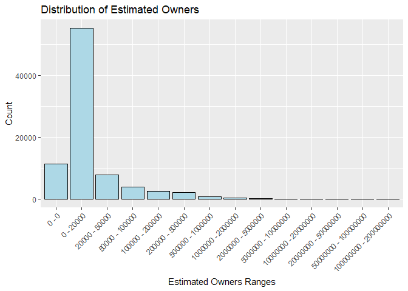

```r
df$Estimated.owners <- factor(df$Estimated.owners,
                              levels = c("0 - 0", "0 - 20000", "20000 - 50000", "50000 - 100000",
                                         "100000 - 200000", "200000 - 500000", "500000 - 1000000",
                                         "1000000 - 2000000", "2000000 - 5000000",
                                         "5000000 - 10000000", "10000000 - 20000000",
                                         "20000000 - 50000000", "50000000 - 100000000",
                                         "100000000 - 200000000"))

# Create the bar plot
ggplot(df, aes(x = Estimated.owners)) +
  geom_bar(fill = "lightblue", color = "black") +
  labs(title = "Distribution of Estimated Owners",
       x = "Estimated Owners Ranges",
       y = "Count") +
  theme(axis.text.x = element_text(angle = 45, hjust = 1))
```

Most of the games have estimated 0 - 20000 owners. The top 3 groups with the highest number of owners (20,000,000 - 50,000,000, 50,000,000 - 100,000,000, and 100,000,000 - 200,000,000) were filtered to find the most owned games.

```r
# Filter for the top 3 ranges
top_games_owned <- df[df$Estimated.owners %in% c("100000000 - 200000000",
                                                 "50000000 - 100000000",
                                                 "20000000 - 50000000"), ]

# Convert Estimated.owners to a numeric range for sorting
top_games_owned$OwnersNumeric <- as.numeric(gsub("[^0-9]", "", sub(
  " - .*", "", top_games_owned$Estimated.owners
)))

# Sort the filtered games in descending order of owners
sorted_games <- top_games_owned[order(-top_games_owned$OwnersNumeric), ]

# Display the result
print(sorted_games)
```

```
## # A tibble: 26 × 19
##    Name       Release.date Estimated.owners Price Windows Mac   Linux User.score
##    <chr>      <date>       <fct>            <dbl> <fct>   <fct> <fct>      <int>
##  1 Dota 2     2013-07-09   100000000 - 200…  0    True    True  True           0
##  2 New World  2021-09-28   50000000 - 1000… 40.0  True    False False          0
##  3 PUBG: BAT… 2017-12-21   50000000 - 1000…  0    True    False False          0
##  4 Team Fort… 2007-10-10   50000000 - 1000…  0    True    True  True           0
##  5 Counter-S… 2012-08-21   50000000 - 1000…  0    True    True  True           0
##  6 Apex Lege… 2020-11-04   20000000 - 5000…  0    True    False False          0
##  7 Garry's M… 2006-11-29   20000000 - 5000…  9.99 True    True  True           0
##  8 Destiny 2  2019-10-01   20000000 - 5000…  0    True    False False          0
##  9 Tom Clanc… 2015-12-01   20000000 - 5000… 20.0  True    False False          0
## 10 War Thund… 2013-08-15   20000000 - 5000…  0    True    True  True           0
## # ℹ 16 more rows
## # ℹ 11 more variables: Positive <int>, Negative <int>, Recommendations <int>,
## #   Average.playtime.forever <int>, Average.playtime.two.weeks <int>,
## #   Median.playtime.forever <int>, Median.playtime.two.weeks <int>,
## #   Genres <chr>, Developers <chr>, Publishers <chr>, OwnersNumeric <dbl>
```

## 4.2 Top publishers

### 4.2.1 Pulishers of the games that have more than 20000000 owners

```r
top_publishers_occurrence <- sorted_games %>%
  group_by(Publishers) %>%
  summarise(Occurrence = n()) %>%
  arrange(desc(Occurrence))

print(top_publishers_occurrence)
```

```
## # A tibble: 19 × 2
##    Publishers                                   Occurrence
##    <chr>                                             <int>
##  1 Valve                                                 6
##  2 Amazon Games                                          2
##  3 Ubisoft                                               2
##  4 Bungie                                                1
##  5 Coffee Stain Publishing                               1
##  6 Digital Extremes                                      1
##  7 Electronic Arts                                       1
##  8 Facepunch Studios                                     1
##  9 FromSoftware Inc.,Bandai Namco Entertainment          1
## 10 Gaijin Distribution KFT                               1
## 11 Grinding Gear Games                                   1
## 12 Innersloth                                            1
## 13 KRAFTON, Inc.                                         1
## 14 Re-Logic                                              1
## 15 Rockstar Games                                        1
## 16 Smartly Dressed Games                                 1
## 17 Starbreeze Publishing AB                              1
## 18 Wallpaper Engine Team                                 1
## 19 Xbox Game Studios                                     1
```

Among the top games that have the most owners, Valve has 6 games in the list, Amazon Games has 2, and Ubisoft has 2.

### 4.2.2 Top publishers by number of games

```r
# Count occurrences of each publisher, excluding empty levels
top_publishers_games <- df %>%
  group_by(Publishers) %>%
  summarise(Number_of_Games = n(), .groups = 'drop') %>%
  filter(Publishers != "") %>%  # Remove empty levels
  arrange(desc(Number_of_Games))

head(top_publishers_games,10)
```

```
## # A tibble: 10 × 2
##    Publishers      Number_of_Games
##    <chr>                     <int>
##  1 Big Fish Games              499
##  2 8floor                      268
##  3 SEGA                        182
##  4 HH-Games                    173
##  5 Strategy First              169
##  6 Square Enix                 162
##  7 Laush Studio                160
##  8 Sekai Project               158
##  9 Choice of Games             154
## 10 Ubisoft                     143
```

These are the top 10 publishers that publish the most games. Big Fish Games dominate other publishers in terms of quantity, with 499 games.

## 4.3 Game genres trends over the years

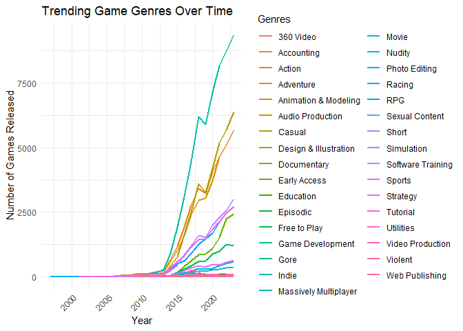

```r
# Create a new column for the year of release
df$Year <- format(df$Release.date, "%Y")
df$Year <- as.numeric(df$Year)

# Separate multiple genres
df_genres <- df %>%
  separate_rows(Genres, sep = ",") %>%
  filter(!is.na(Genres) & Genres != "")  # Remove empty or NA genres

# Count the number of games per genre by year
genre_by_year <- df_genres %>%
  group_by(Year, Genres) %>%
  summarise(Count = n(), .groups = 'drop')

genre_by_year <- genre_by_year %>%
  filter(Year < 2024)

# Create a plot to show the trends over time
ggplot(genre_by_year, aes(x = Year, y = Count, color = Genres)) +
  geom_line(linewidth = 0.8) +
  labs(
    title = "Trending Game Genres Over Time",
    x = "Year",
    y = "Number of Games Released",
    color = "Genres"
  ) +
  theme_minimal() +
  theme(axis.text.x = element_text(angle = 45, hjust = 1)) +
  xlim(1997, NA)
```

The plot shows a significant increase in the number of games released starting around 2010, with a steep rise around 2015 and continuing into the 2020s. Indie, Casual, Adventure, and Action are among the fastest-growing genres in terms of the number of games released over time. There are a wide range of game genres. Some lines show only gradual increases or relatively flat growth, indicating that those genres may be niche or less popular.

### 4.3.1 Top 10 genres of all time

```r
# Count the number of games per genre for all years
top_genres_all <- df_genres %>%
  group_by(Genres) %>%
  summarise(GameCount = n(), .groups = 'drop') %>%
  arrange(desc(GameCount))  # Sort by the count in descending order

head(top_genres_all, 10)
```

```
## # A tibble: 10 × 2
##    Genres       GameCount
##    <chr>            <int>
##  1 Indie            56929
##  2 Casual           34204
##  3 Action           33809
##  4 Adventure        31450
##  5 Simulation       16147
##  6 Strategy         15602
##  7 RPG              14440
##  8 Early Access     10403
##  9 Free to Play      6630
## 10 Sports            3789
```

### 4.3.2 Top 10 genres in 2024

```r
df_2024 <- df_genres %>%
  filter(Year == 2024)

# Count the number of games per genre in 2024
top_genres_2024 <- df_2024 %>%
  group_by(Genres) %>%
  summarise(GameCount = n(), .groups = 'drop') %>%
  arrange(desc(GameCount))  # Sort by the count in descending order

# Print the top genres in 2024 by count
head(top_genres_2024, 10)
```

```
## # A tibble: 10 × 2
##    Genres       GameCount
##    <chr>            <int>
##  1 Indie              180
##  2 Casual             119
##  3 Action             106
##  4 Adventure           97
##  5 Strategy            62
##  6 Simulation          57
##  7 RPG                 50
##  8 Early Access        45
##  9 Racing              15
## 10 Sports              14
```

The top 10 genres of all time and in 2024 lists are not so different. The most popular genres are still Indie, Casual, Action, Adventure, Strategy and Simulation.

## 4.4 Price distriubtion

### 4.4.1 Overall price distribution

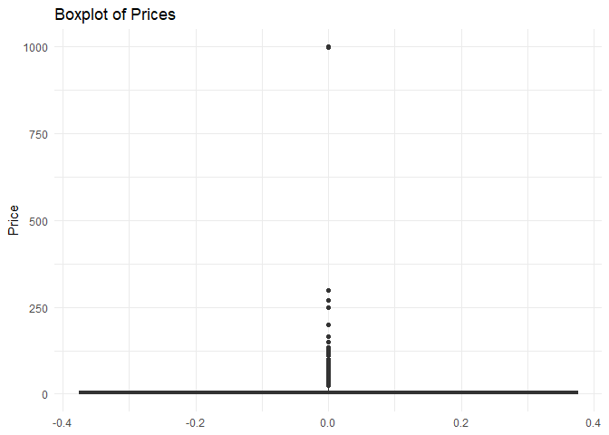

```r
# Create a boxplot of the Price
ggplot(df, aes(y = Price)) +
  geom_boxplot() +
  labs(title = "Boxplot of Prices", y = "Price") +
  theme_minimal()
```

The plot has some extreme outliers. These outliers are eliminated by 1.5 IQR rule.

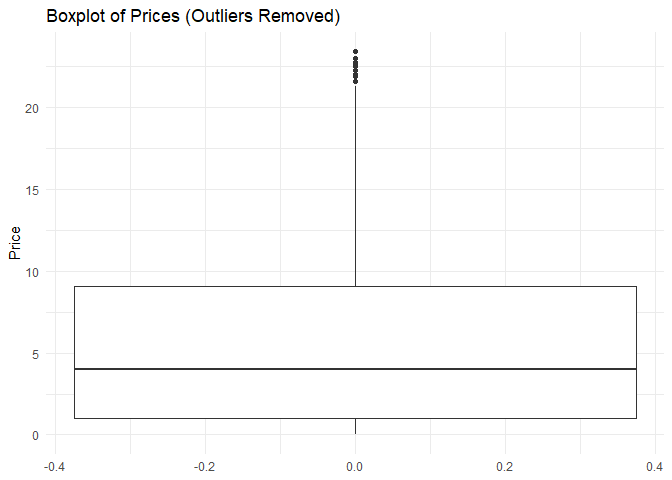

```r
# Calculate Q1, Q3, and IQR
price_Q1 <- quantile(df$Price, 0.25)
price_Q3 <- quantile(df$Price, 0.75)
price_IQR <- price_Q3 - price_Q1

# Define the bounds for outliers
price_lower_bound <- price_Q1 - 1.5 * price_IQR
price_upper_bound <- price_Q3 + 1.5 * price_IQR

# Filter out outliers from the dataset
df_price <- df %>%
  filter(Price >= price_lower_bound & Price <= price_upper_bound)

# Create a boxplot of prices without outliers
ggplot(df_price, aes(y = Price)) +
  geom_boxplot() +
  labs(title = "Boxplot of Prices (Outliers Removed)", y = "Price") +
  theme_minimal()
```

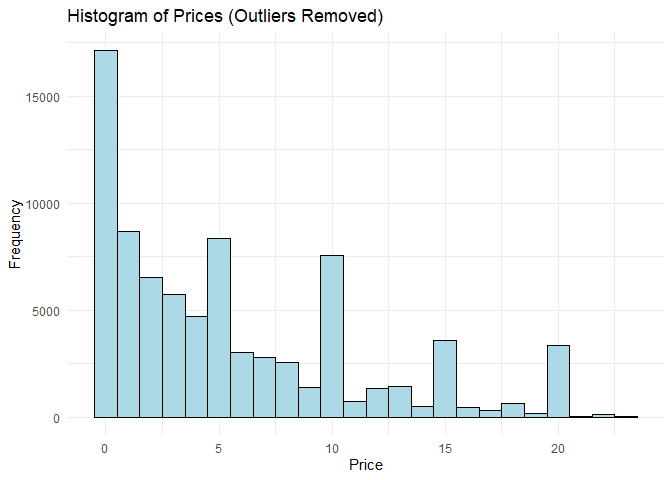

```r
# Create a histogram of the price variable
ggplot(df_price, aes(x = Price)) +
  geom_histogram(binwidth = 1, fill = "lightblue", color = "black") +
  labs(title = "Histogram of Prices (Outliers Removed)", x = "Price", y = "Frequency") +
  theme_minimal()
```

Summary statistics of Price.

```r
summary(df_price$Price)
```

```
##    Min. 1st Qu.  Median    Mean 3rd Qu.    Max.
##   0.000   0.990   3.990   5.518   9.090  23.390
```

The majorities of games (with some outliers with very high prices removed) have prices less than $10; most of which are free or have a very low cost. The median price is about $4. There are noticeable peaks at certain price points (e.g., around $10, $15, and $20), suggesting that there are common pricing strategies or thresholds for games. Among the most owned games, there are only 3 games that have price greater than $20, including New World ($39.99), Elden Ring ($59.99), Rust ($39.99). The majority of the list are free.

### 4.4.2 Price distribution by estimated owners

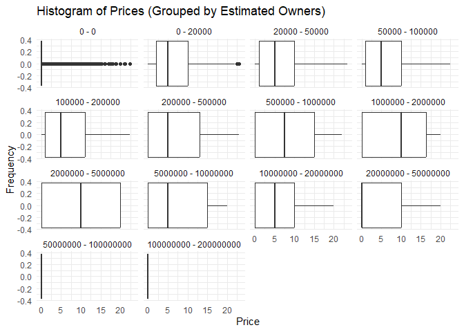

```r
ggplot(df_price, aes(x = Price)) +
  geom_boxplot() +
  labs(title = "Histogram of Prices (Grouped by Estimated Owners)", x = "Price", y = "Frequency") +
  theme_minimal() +
  facet_wrap(~ Estimated.owners)  # Group by 'Estimated.owners' and create separate histograms for each
```

## 4.5 Relationship between genres and prices

```r
# Add a unique ID column to df
df <- df %>%
  mutate(ID = row_number())  # Creates a unique ID for each row

genres_matrix <- df %>%
  select(ID, Genres) %>%  # Select only ID and Genres columns
  separate_rows(Genres, sep = ",") %>%  # Split genres into separate rows
  mutate(value = 1) %>%  # Add a value column to indicate presence of the genre
  spread(key = Genres, value = value, fill = 0)  # One-hot encoding of genres
# Convert all columns except 'ID' to integer type
genres_matrix <- genres_matrix %>%
  mutate(across(-ID, as.integer))  # Convert all genre columns to integer type

# Check the first few rows of genres_matrix
head(genres_matrix)
```

```
## # A tibble: 6 × 35
##      ID    V1 `360 Video` Accounting Action Adventure `Animation & Modeling`
##   <int> <int>       <int>      <int>  <int>     <int>                  <int>
## 1     1     0           0          0      0         0                      0
## 2     2     0           0          0      1         0                      0
## 3     3     0           0          0      1         1                      0
## 4     4     0           0          0      0         1                      0
## 5     5     0           0          0      0         1                      0
## 6     6     0           0          0      0         1                      0
## # ℹ 28 more variables: `Audio Production` <int>, Casual <int>,
## #   `Design & Illustration` <int>, Documentary <int>, `Early Access` <int>,
## #   Education <int>, Episodic <int>, `Free to Play` <int>,
## #   `Game Development` <int>, Gore <int>, Indie <int>,
## #   `Massively Multiplayer` <int>, Movie <int>, Nudity <int>,
## #   `Photo Editing` <int>, Racing <int>, RPG <int>, `Sexual Content` <int>,
## #   Short <int>, Simulation <int>, `Software Training` <int>, Sports <int>, …
```

```r
price_genres <- genres_matrix %>%
  left_join(df %>% select(ID, Price), by = "ID") %>%  # Join Price column using ID
  select(-ID)  # Drop the ID column

# Check the first few rows of price_genres
head(price_genres)
```

```
## # A tibble: 6 × 35
##      V1 `360 Video` Accounting Action Adventure `Animation & Modeling`
##   <int>       <int>      <int>  <int>     <int>                  <int>
## 1     0           0          0      0         0                      0
## 2     0           0          0      1         0                      0
## 3     0           0          0      1         1                      0
## 4     0           0          0      0         1                      0
## 5     0           0          0      0         1                      0
## 6     0           0          0      0         1                      0
## # ℹ 29 more variables: `Audio Production` <int>, Casual <int>,
## #   `Design & Illustration` <int>, Documentary <int>, `Early Access` <int>,
## #   Education <int>, Episodic <int>, `Free to Play` <int>,
## #   `Game Development` <int>, Gore <int>, Indie <int>,
## #   `Massively Multiplayer` <int>, Movie <int>, Nudity <int>,
## #   `Photo Editing` <int>, Racing <int>, RPG <int>, `Sexual Content` <int>,
## #   Short <int>, Simulation <int>, `Software Training` <int>, Sports <int>, …
```

```r
# Now, calculate the correlation between Price and each genre
cor_price_genres <- sapply(price_genres %>% select(-Price), function(x) {
  cor(x, price_genres$Price, use = "complete.obs")
})

# Sort and display the correlations
cor_price_genres <- sort(cor_price_genres, decreasing = TRUE)
print("Price and each genre correlation coefficients")
```

```
## [1] "Price and each genre correlation coefficients"
```

```r
print(cor_price_genres)
```

```
##      Video Production  Animation & Modeling Design & Illustration
##           0.080548114           0.079186909           0.077464378
##            Simulation                   RPG      Audio Production
##           0.074502883           0.061552486           0.061377395
##      Game Development                Sports             Adventure
##           0.057420609           0.045638728           0.044075805
##         Photo Editing     Software Training              Strategy
##           0.042877945           0.042468600           0.039085419
##             Utilities             Education          Early Access
##           0.036216065           0.035637679           0.034963092
##        Web Publishing                Racing                Action
##           0.033138647           0.031002427           0.020810048
##            Accounting             360 Video           Documentary
##           0.007486154          -0.001720230          -0.001720230
##              Episodic                 Short              Tutorial
##          -0.001720230          -0.001720230          -0.001720230
##                 Movie        Sexual Content                Nudity
##          -0.002626932          -0.004060575          -0.004288040
##                  Gore               Violent Massively Multiplayer
##          -0.008152269          -0.010909924          -0.031374117
##                 Indie                Casual                    V1
##          -0.087281396          -0.104992736          -0.118897814
##          Free to Play
##          -0.163619651
```

The “Free to Play” genre and Price have the highest correlation in the list, which is approximately -0.1636. However, this correlation is quite weak, indicating that there is almost no relationship between Price and the Genres.

## 4.6 Relationship between variables

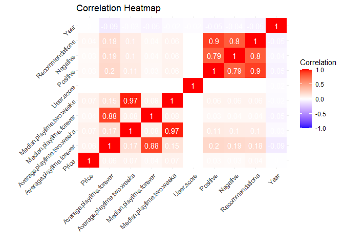

```r
cor_matrix <- df %>%
  select(Price, Average.playtime.forever, Average.playtime.two.weeks, Median.playtime.forever, Median.playtime.two.weeks, User.score, Positive, Negative, Recommendations, Year) %>%
  cor(use = "complete.obs")

cor_matrix <- as.data.frame(as.table(cor_matrix))
colnames(cor_matrix) <- c("Var1", "Var2", "Correlation")

# Plot the correlation heatmap
ggplot(cor_matrix, aes(Var1, Var2, fill = Correlation)) +
  geom_tile() +
  geom_text(aes(label = round(Correlation, 2)), color = "white", size = 4) +
  scale_fill_gradient2(low = "blue", high = "red", mid = "white", midpoint = 0, limit = c(-1, 1)) +
  labs(title = "Correlation Heatmap", x = "", y = "") +
  theme_minimal() +
  theme(axis.text.x = element_text(angle = 45, hjust = 1),
        axis.text.y = element_text(angle = 45, hjust = 1))
```

The correlation heatmap reveals strong relationships between the Positive, Negative, and Recommendations variables, indicating that these factors are closely related to one another. *The Price is not correlated to any other variables. This may imply that the pricing strategy for these games is influenced by other factors not captured in this dataset, or that pricing decisions are largely independent of other observed metrics.* The median and mean play time show weak correlations with the median and mean play time forever. This indicates that a game’s long-term playtime is not necessarily indicative of its more recent playtime.

### 4.6.1 Relationship between postive and negative ratings

The variables Positive, Negative, and Recommendations depend on the total the number of owners of all the games. The analysis of the relationships between these variables is conducted by grouping the data based on the estimated number of owners.

```r
df_rating <- df %>%
  group_by(Estimated.owners) %>%  # Group by 'Estimated.owners'
  summarise(
    total_positive = sum(Positive, na.rm = TRUE),  # Sum of Positive ratings for each group
    total_negative = sum(Negative, na.rm = TRUE),  # Sum of Negative ratings for each group
    mean_positive = mean(Positive, na.rm = TRUE),
    mean_negative = mean(Negative, na.rm = TRUE),
    median_positive = median(Positive, na.rm = TRUE),
    median_negative = median(Negative, na.rm = TRUE),
    total_ratings = total_positive + total_negative,
    positive_percentage = total_positive / total_ratings * 100,
    negative_percentage = total_negative / total_ratings * 100
  )
```

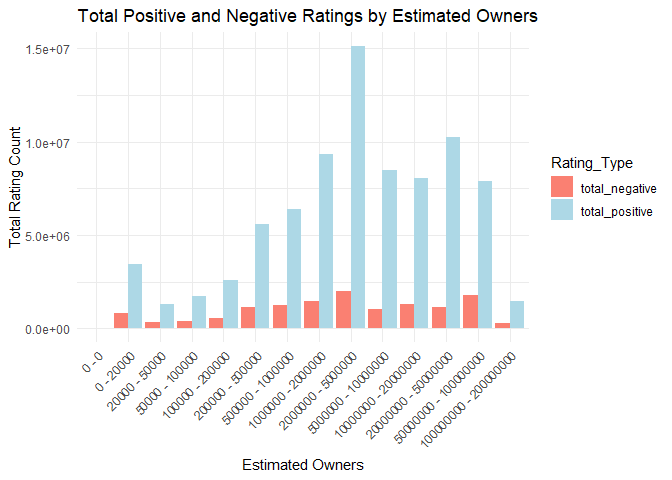

```r
# Create the grouped bar plot
df_rating_grouped <- df_rating %>%
  pivot_longer(cols = c(total_positive, total_negative),
               names_to = "Rating_Type",
               values_to = "Total_Rating")

ggplot(df_rating_grouped, aes(x = Estimated.owners, y = Total_Rating, fill = Rating_Type)) +
  geom_bar(stat = "identity", position = "dodge") +
  labs(title = "Total Positive and Negative Ratings by Estimated Owners",
       x = "Estimated Owners",
       y = "Total Rating Count") +
  theme_minimal() +
  scale_fill_manual(values = c("total_positive" = "lightblue", "total_negative" = "salmon")) +
  theme(
    axis.text.x = element_text(angle = 45, hjust = 1)  # Rotate x-axis labels by 45 degrees
  )
```

The plot shows that the number of of Postitive ratings outnumber that of Negative ratings.

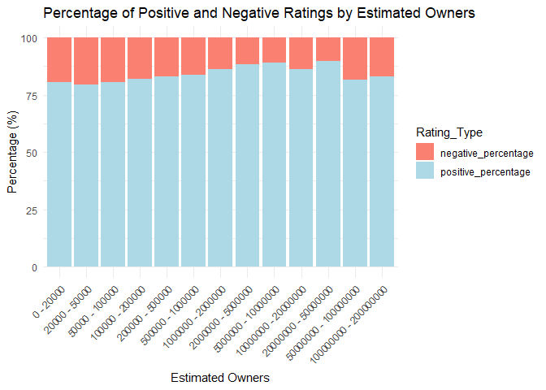

```r
df_rating <- df_rating %>% filter(Estimated.owners != "0 - 0")  # there is no data in group 0 - 0

# Pivot the data to long format for stacked bar plot
df_rating_stacked <- df_rating %>%
  pivot_longer(
    cols = c(positive_percentage, negative_percentage),
    names_to = "Rating_Type",
    values_to = "Percentage"
  )

# Plot the stacked bar chart
ggplot(df_rating_stacked,
       aes(x = Estimated.owners, y = Percentage, fill = Rating_Type)) +
  geom_bar(stat = "identity", position = "stack") +  # Position "stack" to stack the bars
  labs(title = "Percentage of Positive and Negative Ratings by Estimated Owners", x = "Estimated Owners", y = "Percentage (%)") +
  theme_minimal() +
  scale_fill_manual(values = c(
    "positive_percentage" = "lightblue",
    "negative_percentage" = "salmon"
  )) +
  theme(axis.text.x = element_text(angle = 45, hjust = 1))
```

There are only minor variations in the proportion of positive evaluations to all ratings among the various estimated owner groups. This may imply that the percentage of favorable feedback stays comparatively stable, irrespective of the size of the user base.

### 4.6.2 Relationship between postitive ratings and reccommendations

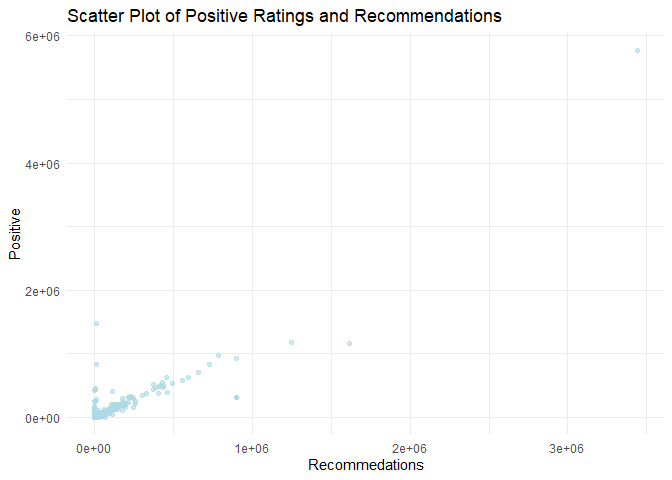

```r
# Scatter plot to visualize the relationship
ggplot(df, aes(x = Recommendations, y = Positive)) +
  geom_point(alpha = 0.6, , color = "lightblue") +
  labs(title = "Scatter Plot of Positive Ratings and Recommendations", x = "Recommedations", y = "Positive") +
  theme_minimal()
```

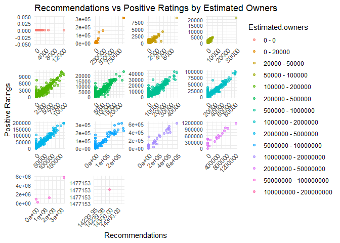

```r
ggplot(df,
       aes(x = Recommendations, y = Positive, color = Estimated.owners)) +
  geom_point(alpha = 0.6) +  # Scatter plot with some transparency for better visibility
  labs(title = "Recommendations vs Positive Ratings by Estimated Owners", x = "Recommendations", y = "Positive Ratings") +
  theme_minimal() +
  facet_wrap( ~ Estimated.owners, scales = "free") +  # Group by 'Estimated.owners'
  theme(
    axis.text.x = element_text(angle = 45, hjust = 1),
    # Rotate x-axis labels
    axis.text.y = element_text(size = 8),
    # Reduce size of y-axis labels
    strip.text = element_blank(),
    # Remove facet labels (titles)
  )
```

The plot shows there is a strong correlation between Recommendations and Positive variables. This suggests that games that are well-received by users (high positive ratings) are more likely to be recommended.

# 5 Regression Model

From the graphs in session 4.6.2, there appears to be a linear relationship between Positive and Recommendations. Linear regression is chosen to model the relationship between these two variables.

Due to incomplete or inconsistent data collection processes, both the Recommendations and Positive variables contain a significant number of zero values. These zero values are likely a result of missing or unrecorded information during data acquisition. Therefore, all records with zero values in either of these variables have been excluded from the analysis to ensure the dataset better reflects the underlying relationships.

```r
df_RP <- df %>% filter(Estimated.owners != "0 - 0") %>%
  select(Recommendations, Positive)

# Remove outliers where 'Recommendations' > 1e+06
df_RP <- df_RP %>% filter(!(Recommendations == 0 | Positive == 0))
df_RP <- df_RP[df_RP$Recommendations < 1e+06, ]

summary(df_RP)
```

```
##  Recommendations     Positive
##  Min.   :   101   Min.   :     10
##  1st Qu.:   187   1st Qu.:    188
##  Median :   420   Median :    438
##  Mean   :  4471   Mean   :   5280
##  3rd Qu.:  1453   3rd Qu.:   1590
##  Max.   :899838   Max.   :1477153
```

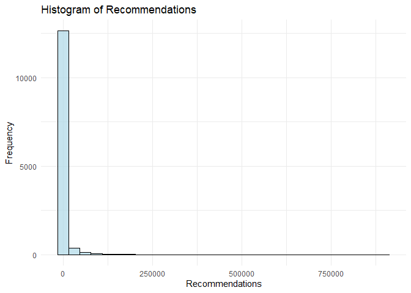

```r
# Plot histogram for Recommendations
ggplot(df_RP, aes(x = Recommendations)) +
  geom_histogram(fill = "lightblue", color = "black", alpha = 0.7) +
  labs(title = "Histogram of Recommendations", x = "Recommendations", y = "Frequency") +
  theme_minimal()
```

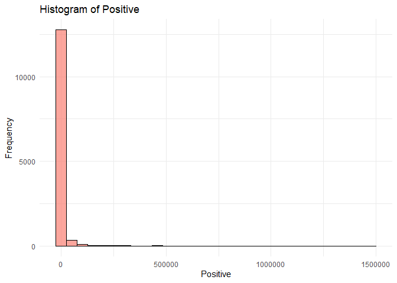

```r
# Plot histogram for Positive
ggplot(df_RP, aes(x = Positive)) +
  geom_histogram(fill = "salmon", color = "black", alpha = 0.7) +
  labs(title = "Histogram of Positive", x = "Positive", y = "Frequency") +
  theme_minimal()
```

The data for both Recommendations and Positive variables exhibits an extreme right-skewed distribution. To address this issue and make the data more suitable for analysis, a log transformation is applied. This transformation aims to mitigate the effect of outliers and achieve a more symmetric, less skewed distribution that better supports modeling and hypothesis testing.

```r
# Apply log transformation
df_RP$log_Recommendations <- log(df_RP$Recommendations)
df_RP$log_Positive <- log(df_RP$Positive)

# Check the summary statistics of the transformed variables
summary(df_RP)
```

```
##  Recommendations     Positive       log_Recommendations  log_Positive
##  Min.   :   101   Min.   :     10   Min.   : 4.615      Min.   : 2.303
##  1st Qu.:   187   1st Qu.:    188   1st Qu.: 5.231      1st Qu.: 5.236
##  Median :   420   Median :    438   Median : 6.040      Median : 6.082
##  Mean   :  4471   Mean   :   5280   Mean   : 6.447      Mean   : 6.483
##  3rd Qu.:  1453   3rd Qu.:   1590   3rd Qu.: 7.281      3rd Qu.: 7.371
##  Max.   :899838   Max.   :1477153   Max.   :13.710      Max.   :14.206
```

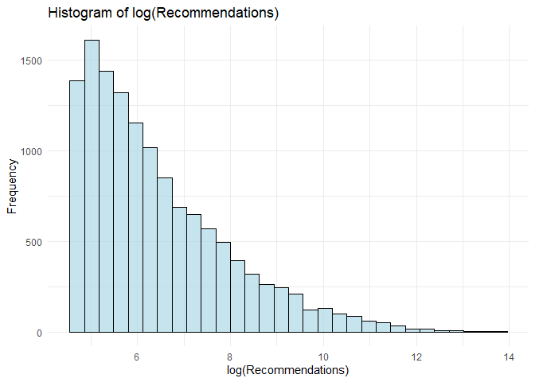

```r
# Plot histogram for Recommendations
ggplot(df_RP, aes(x = log_Recommendations)) +
  geom_histogram(fill = "lightblue", color = "black", alpha = 0.7) +
  labs(title = "Histogram of log(Recommendations)", x = "log(Recommendations)", y = "Frequency") +
  theme_minimal()
```

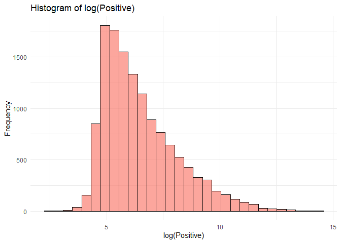

```r
# Plot histogram for Positive
ggplot(df_RP, aes(x = log_Positive)) +
  geom_histogram(fill = "salmon", color = "black", alpha = 0.7) +
  labs(title = "Histogram of log(Positive)", x = "log(Positive)", y = "Frequency") +
  theme_minimal()
```

Despite applying the log transformation to both the Recommendations and Positive variables, the data still exhibits right skewness, although the distribution has improved significantly.

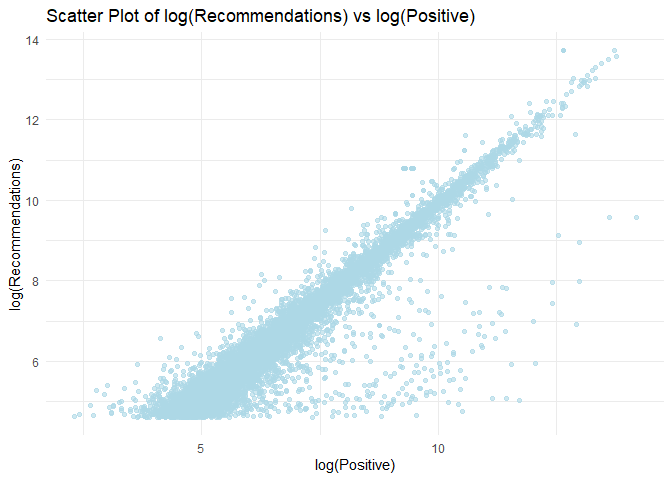

```r
# Create the scatter plot of log_Recommendations vs. log_Positive
ggplot(df_RP, aes(x = log_Positive, y = log_Recommendations)) +
  geom_point(color = "lightblue", alpha = 0.6) +  # Add points with color and transparency
  labs(title = "Scatter Plot of log(Recommendations) vs log(Positive)",
       x = "log(Positive)",
       y = "log(Recommendations)") +
  theme_minimal()  # Apply a minimal theme for the plot
```

The scatter plot shows that there appears to be a strong linear relationship between log(Recommendations) and log(Positive). However, there are multiple outliers.

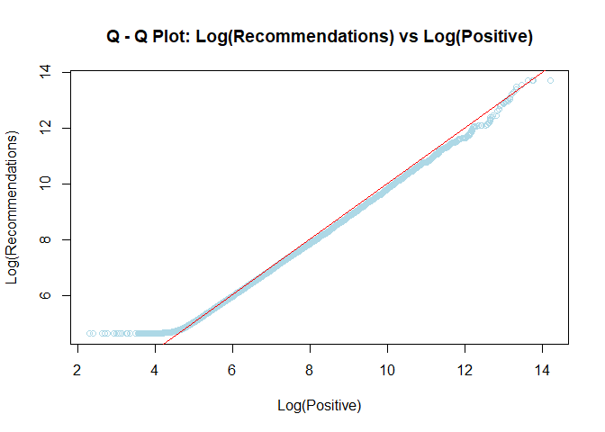

```r
# Q-Q plot to visualize the relationship between log_Recommendations and log_Positive
qqplot(df_RP$log_Positive, df_RP$log_Recommendations,
     main = "Q - Q Plot: Log(Recommendations) vs Log(Positive)",
     xlab = "Log(Positive)", ylab = "Log(Recommendations)",
     col = "lightblue") # Adjust transparency with rgb()

abline(0, 1, col = "red")
```

The fact that most of the points lie very close to the 45-degree diagonal line suggests that, for the majority of the data, log_Recommendations and log_Positive have a very similar distribution. For the central part of the data, the two variables are closely correlated and exhibit a similar pattern of values. There are deviations at tails.

Given that the data remains skewed even after the log transformation, the chosen model for analysis is the robust linear regression model. Unlike traditional Ordinary Least Squares (OLS) regression, which assumes that the errors are normally distributed and are equally spread, the robust linear regression model is designed to be less sensitive to outliers and violations of such assumptions. The robustbase package provides tools for robust regression.

```r
library(robustbase)
# Fit robust regression model
model_robust <- lmrob(log_Positive ~ log_Recommendations, data = df_RP)

# Summarize the model
summary(model_robust)
```

```
##
## Call:
## lmrob(formula = log_Positive ~ log_Recommendations, data = df_RP)
##  \--> method = "MM"
## Residuals:
##       Min        1Q    Median        3Q       Max
## -2.467060 -0.120612  0.007505  0.131651  6.761907
##
## Coefficients:
##                      Estimate Std. Error t value Pr(>|t|)
## (Intercept)         -0.169468   0.008075  -20.99   <2e-16 ***
## log_Recommendations  1.023833   0.001139  899.24   <2e-16 ***
## ---
## Signif. codes:  0 '***' 0.001 '**' 0.01 '*' 0.05 '.' 0.1 ' ' 1
##
## Robust residual standard error: 0.1968
## Multiple R-squared:  0.9832, Adjusted R-squared:  0.9832
## Convergence in 10 IRWLS iterations
##
## Robustness weights:
##  528 observations c(27,39,44,119,126,130,132,136,137,162,169,182,222,239,263,293,337,345,357,406,412,447,458,555,558,561,591,624,632,649,677,680,738,808,817,826,831,889,893,912,989,1049,1064,1076,1085,1091,1108,1125,1189,1205,1207,1210,1221,1281,1300,1361,1363,1371,1378,1387,1391,1418,1487,1522,1…
##   are outliers with |weight| = 0 ( < 7.5e-06);
##  1311 weights are ~= 1. The remaining 11407 ones are summarized as
##      Min.   1st Qu.    Median      Mean   3rd Qu.      Max.
## 0.0000351 0.8402000 0.9557000 0.8625000 0.9885000 0.9990000
## Algorithmic parameters:
##        tuning.chi                bb        tuning.psi        refine.tol
##         1.548e+00         5.000e-01         4.685e+00         1.000e-07
##           rel.tol         scale.tol         solve.tol          zero.tol
##         1.000e-07         1.000e-10         1.000e-07         1.000e-10
##       eps.outlier             eps.x warn.limit.reject warn.limit.meanrw
##         7.549e-06         2.494e-11         5.000e-01         5.000e-01
##      nResample         max.it         groups        n.group       best.r.s
##            500             50              5            400              2
##       k.fast.s          k.max    maxit.scale      trace.lev            mts
##              1            200            200              0           1000
##     compute.rd fast.s.large.n
##              0           2000
##                   psi           subsampling                   cov
##            "bisquare"         "nonsingular"         ".vcov.avar1"
## compute.outlier.stats
##                  "SM"
## seed : int(0)
```

```
## recomputing robust Mahalanobis distances
```

```
## saving the robust distances 'MD' as part of 'model_robust'
```

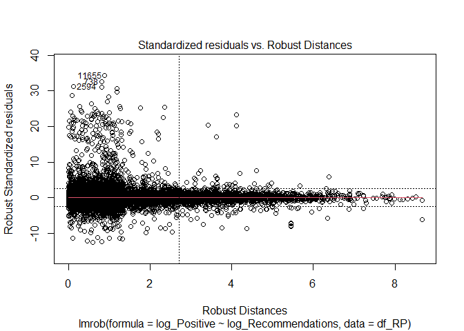

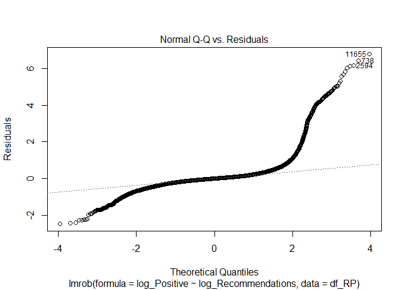

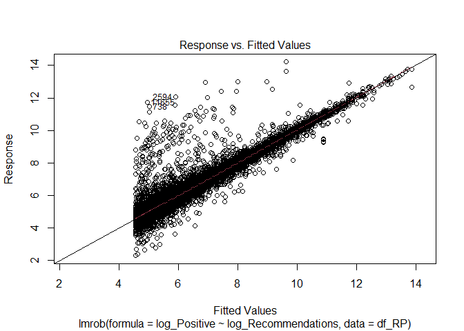

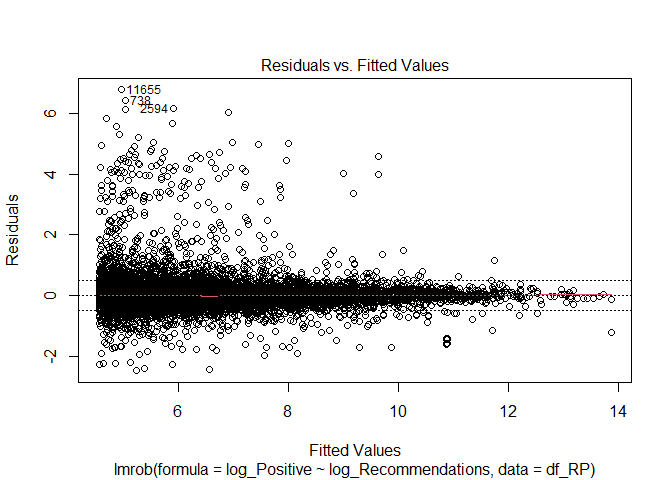

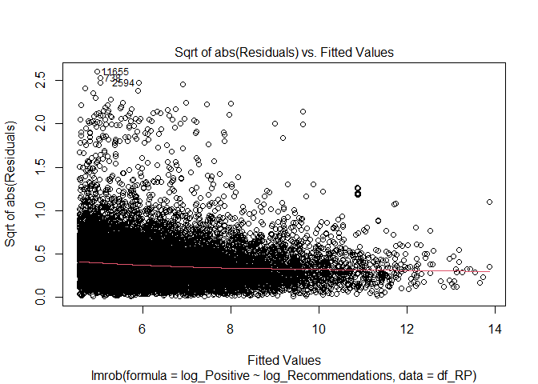

```r
plot(model_robust)
```

According to the plots, there are some outliers such as observations 2594, 738, and 11655 that appear to deviate significantly from the overall pattern of the data. The residuals in Q-Q Normal Plot have heavy tails and are skewed, which indicates a deviation from normality, and possibly suggests that extreme values or outliers are affecting the model fit. However, the residuals closely follow the reference line within the quantile range of -1.5 to 1.5. This indicates that, for the majority of the data, the residuals behave approximately normally. All the plots likely show a linear relationship, indicating that the model has captured the linear trend well.

# 6 Hypothesis Testing

## 6.1 Positive and negative ratings by estimated Owners

Does the number of Positive and Negative ratings vary for games that have a higher number of Estimated owners?

- Null Hypothesis ($H_0$): Ratings (Positive and Negative) and Estimated owners are independent.
- Alternative Hypothesis ($H_1$): Ratings (Positive and Negative) and Estimated owners are dependent.

```r
contingency_table1 <- data.frame(
  owner_category = df_rating$Estimated.owners,
  total_positive = df_rating$total_positive,
  total_negative = df_rating$total_negative
  # proportion_positive = df_rating$total_positive / (df_rating$total_positive + df_rating$total_negative),
  # proportion_negative = df_rating$total_negative / (df_rating$total_positive + df_rating$total_negative)
)

print(contingency_table1)
```

```
##           owner_category total_positive total_negative
## 1              0 - 20000        3447257         834024
## 2          20000 - 50000        1311788         340622
## 3         50000 - 100000        1714681         412396
## 4        100000 - 200000        2590052         569498
## 5        200000 - 500000        5562721        1128554
## 6       500000 - 1000000        6365916        1237058
## 7      1000000 - 2000000        9340266        1472258
## 8      2000000 - 5000000       15108610        2013798
## 9     5000000 - 10000000        8488768        1043464
## 10   10000000 - 20000000        8035589        1289487
## 11   20000000 - 50000000       10235548        1162149
## 12  50000000 - 100000000        7897682        1793238
## 13 100000000 - 200000000        1477153         300437
```

```r
contingency_matrix1 <- as.matrix(contingency_table1[, c("total_positive", "total_negative")])
# contingency_matrix1b <- as.matrix(contingency_table1[, c("proportion_positive", "proportion_negative")])
```

The Chi-square test of independence checks whether if variables are likely to be related or not.

```r
# Perform the Chi-squared test with total_positive and total_negative
chi_square_result1 <- chisq.test(contingency_matrix1)
print(chi_square_result1)
```

```
##
##  Pearson's Chi-squared test
##
## data:  contingency_matrix1
## X-squared = 778399, df = 12, p-value < 2.2e-16
```

Since p-value is much less than 0.01, at the 1% level of significance, we reject the null hypothesis ($H_0$), and accept the alternative hypothesis ($H_1$). In conclusion, *ratings (Positive and Negative) and Estimated owners are dependent.*

## 6.2 Effect of multiple genres on positive and negative ratings

Does the presence of multiple genres in a game affect the number of Positive and Negative ratings?

- Null Hypothesis ($H_0$): Ratings (Positive and Negative) and the number of genres are independent.
- Alternative Hypothesis ($H_1$): Ratings (Positive and Negative) and the number of genres are dependent.

```r
df$multiple_genres <- sapply(strsplit(as.character(df$Genres), ","), length)
df$multiple_genres <- ifelse(df$multiple_genres > 9, "10+", df$multiple_genres)

# Convert the column to a factor
df$multiple_genres <- factor(df$multiple_genres, levels = c("0", "1", "2", "3", "4", "5", "6", "7", "8", "9", "10+"))

# View the updated column
table(df$multiple_genres)
```

```
##
##     0     1     2     3     4     5     6     7     8     9   10+
##  3555 12664 22937 23571 13084  5945  2207   737   216   132    45
```

Compare number of positive and negative ratings between single and multiple-genre games

```r
ratings_by_genre <- df %>%
  group_by(multiple_genres) %>%
  summarise(
    total_positive = sum(Positive, na.rm = TRUE),
    total_negative = sum(Negative, na.rm = TRUE)
  )

print(ratings_by_genre)
```

```
## # A tibble: 11 × 3
##    multiple_genres total_positive total_negative
##    <fct>                    <int>          <int>
##  1 0                       128744          13161
##  2 1                     18282258        2770811
##  3 2                     27583890        3965349
##  4 3                     17481165        2817220
##  5 4                      9635482        2254489
##  6 5                      5657256        1101657
##  7 6                      1955348         470606
##  8 7                       727968         158523
##  9 8                        86607          33146
## 10 9                        32046           9304
## 11 10+                       5267           2717
```

```r
contingency_matrix2 <- as.matrix(ratings_by_genre[, c("total_positive", "total_negative")])
```

Similarly, Chi-square test of independence is performed.

```r
chi_square_genre_result2 <- chisq.test(contingency_matrix2)
print(chi_square_genre_result2)
```

```
##
##  Pearson's Chi-squared test
##
## data:  contingency_matrix2
## X-squared = 421504, df = 10, p-value < 2.2e-16
```

Since p-value is much less than 0.01, at the 1% level of significance, we reject the null hypothesis ($H_0$) and accept the alternative hypothesis ($H_1$). *Ratings (Positive and Negative) and the number of genres are dependent.*

# 7 References

Abdalrhman Alkabani’s [Games data cleaning, analysis , and visualization](https://www.kaggle.com/code/abdalrhmanalkabani/games-data-cleaning-analysis-and-visualization#Data-visulization): the notebook conducts exploratory data analysis in python and explores multiple issues such as most downloaded games, price distribution, top publishers, top genres …

# 8 Conclusions

In summary, the Exploratory Data Analysis of Steam Games has provided several key insights into the gaming market on the platform. The study has identified the most popular games based on the number of owners, as well as the leading publishers, determined by both the number of owners and the volume of games published. Additionally, the analysis of trending genres shows a growing popularity across most genres, with Indie, Casual, Adventure, and Action being among the most popular. The price analysis illustrates that most games are either free or have relatively low price, with median price $4; there may be common pricing strategies or pricing thresholds around the $5, $10, $15, and $20 marks.

The study discovers the relationships between variables through a heatmap, and finds a strong linear correlation between Positive ratings and Recommendations through linear regression analysis. This analysis suggests that players are more likely to recommend games with more positive ratings. In addition, the hypothesis tests show that there are relations between ratings (Positive and Negative) and number of owners, and between ratings and number of genres.

Through this study, it seems that both ratings and estimated ownership are important to understand the success of a game, and these factors are closely linked. Games with a larger player base tend to generate more user feedback, which can offer valuable insights for developing and marketing strategies.

However, this study has certain limitations. The data is highly skewed, with numerous outliers and zero values, which may result from limitations in the data collection process. Because of this reason, the study does not account for other potential factors such as play time, which could offer valuable insights into user engagement and satisfaction. Another limitation is that many variables were omitted to simplify the study. By focusing on a fewer variables, the study might have overlooked crucial elements that could have offered a more thorough comprehension of the factors affecting game success.

For future research, incorporating a wider range of variables would provide a more comprehensive understanding of the games on the Steam platform. Considering these additional factors could lead to more accurate and valuable insights.

# 9 Appendix

## 9.1 Most popular platforms (Windows, Linux, Mac)

```r
windows_count <- sum(df$Windows == "True")
mac_count <- sum(df$Mac == "True")
linux_count <- sum(df$Linux == "True")

cat("Games that support Windows:", windows_count, "\n")
```

```
## Games that support Windows: 85063
```

```r
cat("Games that support Mac:", mac_count, "\n")
```

```
## Games that support Mac: 16391
```

```r
cat("Games that support Linux:", linux_count, "\n")
```

```
## Games that support Linux: 11196
```

The number of games that support Windows outnumber those supporting Mac and Linux. Windows is, therefore, the most popular operating system for gaming.